# CFUassay Figure for Gat201 paper

Liz Hughes

31/10/2022

up arrow + fn + L = |

```r
library(reshape2)
library(ggplot2)
library(tidyverse)
library(dplyr)
library(rlang)
library(cowplot)
library(tidyr)
theme_set(theme_bw())
library(ggnewscale)
library(knitr)
library(markdown)
```

# Cfu Assay.

I have collated OD measurements and average cell counts (from Cfu assays).

31-10-2022 Comparison of growth of H99 and Gat 201 mutant (003; Madhan) and 2 Gat201 complemented strains into the Madhani deletion background in RPMI and RPMI + Serum (10% FBS) at 37 degrees over a 60 hour time course. Samples were collected at 4, 12, 24, 36, 48 and 60 hours post inoculation into fresh media.

Samples were collected at 4, 12, 24, 36, 48 and 60 hours post inoculation into fresh media. A 1:10 deletion series was carries out from neat to 10e-4. 100 microlitres of dilutions 10e3 and 10e4 were plated out onto YPD Agar, incubated for 48 hours and colonies counted.

The average of cells/ml over the 2 deletions were used as input for the data analysis.

## Read in data as csv file

```r
rawdata <- read.csv("../Input/221025_Cfu60_RRS.csv")
```

## Create Cfu plot

### First look at data.

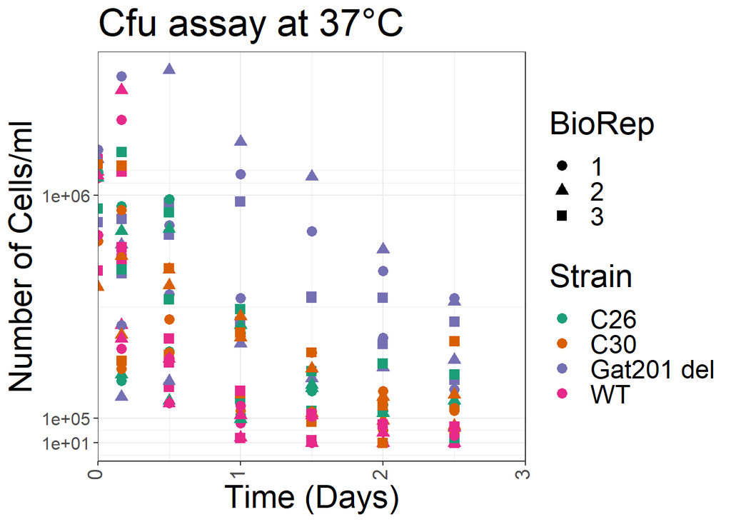

```r
rawdata_day <- mutate(rawdata,
                      Time = Time/24,
                      BioRep=as.factor(BioRep))



Cfu_Plot <- ggplot(rawdata_day,
                      aes(x=Time, y=Cells, colour = Strain)) +
            geom_point(aes(shape = BioRep), size=3) +

                      labs(x="Time (Days)",
                           y="Number of Cells/ml",
                      title = "Cfu assay at 37⁰C") +
                      theme(text = element_text(size = 22)) +
                      scale_x_continuous(expand = c(0, 0), breaks = 0:3, limits = c(0,3)) +
                      scale_y_continuous(breaks = c(10, 100000,  1000000, 10000000))+
                      theme(axis.text.x = element_text(angle = 90, hjust=1, vjust = 0.25, size = 14))+
                      theme(axis.text.y = element_text(size= 12))+
                      scale_color_brewer(palette="Dark2")


Cfu_Plot
```

## Create mean Cfu plot all: Solid line

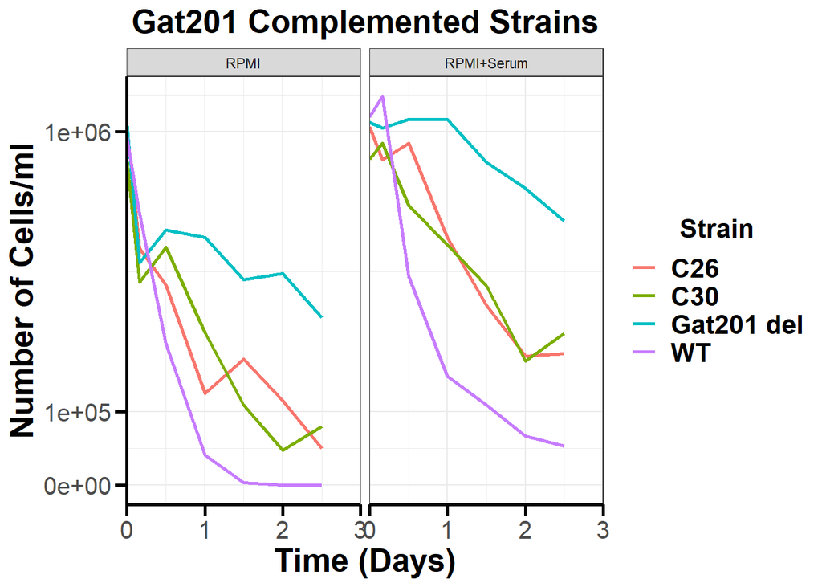

```r
rawdata_day<-mutate(rawdata, Time = Time/24)



Cfu_Plot <- ggplot(rawdata_day,
                  aes(x=Time, y=Cells, colour = Strain)) +
                  labs(x="Time (Days)",
                       y="Number of Cells/ml",
                       title = "Gat201 Complemented Strains") +
                  scale_x_continuous(expand = c(0, 0), breaks = 0:3, limits = c(0,3)) +
                  scale_y_continuous(trans=scales::pseudo_log_trans(sigma =100000, base =  exp(1)),
                                     breaks = c(0, 100000,  1000000, 10000000)) +
  facet_wrap(Media ~ .) +
  theme(
        plot.title = element_text(size = 20, face = "bold", hjust = 0.5,family = "sans"),
        axis.title = element_text(size =20, face = "bold", colour = "black",family = "sans"),
        axis.text = element_text(size = 15,family = "sans"),
        axis.text.x = element_text(hjust =0.5),
        axis.line = element_line(colour = "black", size = 1, linetype = "solid"),
        panel.background = element_rect(fill = "white"),
        axis.ticks = element_line(colour = "black", size = 1),
        axis.ticks.length = unit(0.25, "cm"),
        legend.title = element_text(size = 16, face = "bold", hjust = 0.5),
        legend.text = element_text(size = 16, face = "bold")
        )

Cfu_Plot_mean <-  Cfu_Plot +
                  stat_summary(aes(group = Strain),
                               fun = mean, geom="line",
                               linetype = "solid",
                               size = 1,
                               panel.background = element_rect(fill = "white"))

Cfu_Plot_mean
```

## Create mean Cfu plot all: Dash line

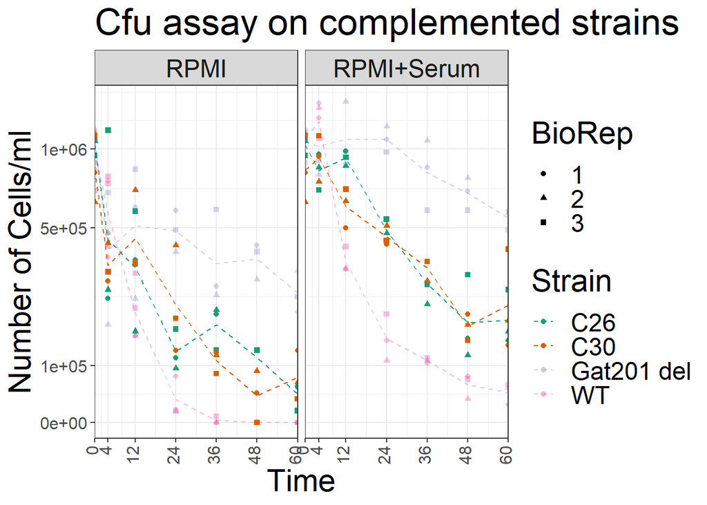

```r
rawdata_day <- mutate(rawdata,
                      BioRep=as.factor(BioRep))


Cfu_Plot2 <- ggplot(rawdata_day,
                    aes(x=Time, y=Cells, colour = Strain, alpha = Strain)) +

            geom_point(aes(shape = BioRep), size=1.5)+
                      scale_alpha_manual(values=c(1,1,0.3,0.3))+
                      facet_grid(~Media) +
                      labs(x="Time",
                           y="Number of Cells/ml",
                           title = "Cfu assay on complemented strains") +
                      theme(text = element_text(size = 22)) +
                      scale_x_continuous(expand = c(0, 0),  breaks = c(0, 4,12, 24,36,48,60)) +
                      scale_y_continuous(trans=scales::pseudo_log_trans(sigma =100000, base =  exp(1)),
                            breaks = c(0, 100000, 500000, 1000000, 5000000))+
                      theme(axis.text.x = element_text( angle = 90,hjust=1, vjust = 0.25, size = 12))+
                      theme(axis.text.y = element_text(size= 12))+
                      scale_color_brewer(palette="Dark2")

Cfu_Plot2_mean <-  Cfu_Plot2 +
                   stat_summary(aes(group = Strain),
                                fun = mean, geom="line",
                                linetype = "dashed")


Cfu_Plot2_mean
```

```r
ggsave("../Results/mean_plot_all_RRS.png",
       width = 10,height=6)
```

## Create mean Cfu plot WT + Gat201 in RPMI: Dash line

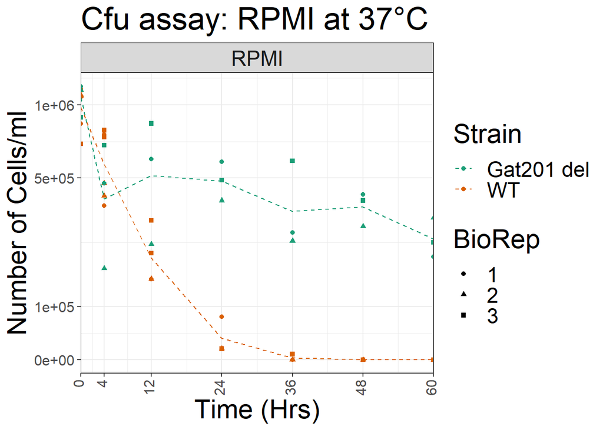

```r
rawdata_day <- mutate(rawdata,
                      BioRep=as.factor(BioRep))

Cfu_Plot_R <- ggplot(rawdata_day %>%
                      filter(Media == "RPMI", Strain == "WT" | Strain =="Gat201 del"),
                      aes(x=Time, y=Cells, colour = Strain)) +

              geom_point(aes(shape = BioRep), size=1.5) +
              facet_grid(~Media) +
              labs(x="Time (Hrs)",
                   y="Number of Cells/ml",
                   title = "Cfu assay: RPMI at 37⁰C") +
              theme(text = element_text(size = 22)) +
              scale_x_continuous(expand = c(0, 0),  breaks = c(0, 4,12, 24,36,48,60)) +
              scale_y_continuous(trans=scales::pseudo_log_trans(sigma =100000, base =  exp(1)),
                    breaks = c(0, 100000, 500000, 1000000, 5000000))+
              theme(axis.text.x = element_text( angle = 90,hjust=1, vjust = 0.25, size = 12))+
              theme(axis.text.y = element_text(size= 12))+
              scale_color_brewer(palette="Dark2")

Cfu_Plot_mean_R <-  Cfu_Plot_R +
    stat_summary(aes(group = Strain), fun = mean, geom="line", linetype = "dashed")

Cfu_Plot_mean_R
```

```r
ggsave("../Results//mean_plot_WTvGat201_R.png",
       width = 8,height=6)
```

## Create mean Cfu plot WT + Gat201 in RPMI + Serum: Dash line

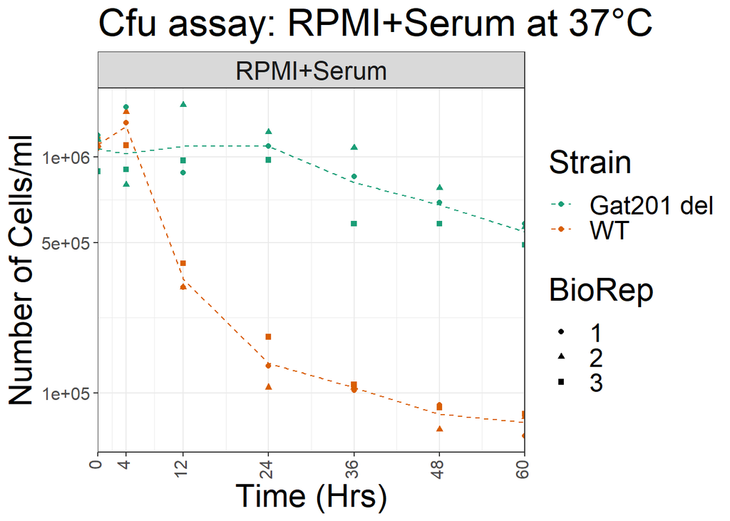

```r
rawdata_day <- mutate(rawdata,
                      BioRep=as.factor(BioRep))

Cfu_Plot_RS <- ggplot(rawdata_day %>%
                    filter(Media == "RPMI+Serum", Strain == "WT" | Strain =="Gat201 del"),
                    aes(x=Time, y=Cells, colour = Strain)) +

              geom_point(aes(shape = BioRep), size=1.5) +
              facet_grid(~Media) +
              labs(x="Time (Hrs)",
                   y="Number of Cells/ml",
                   title = "Cfu assay: RPMI+Serum at 37⁰C") +
              theme(text = element_text(size = 22)) +
              scale_x_continuous(expand = c(0, 0),  breaks = c(0, 4,12, 24,36,48,60)) +
              scale_y_continuous(trans=scales::pseudo_log_trans(sigma =100000, base =  exp(1)),
                    breaks = c(0, 100000, 500000, 1000000, 5000000))+
              theme(axis.text.x = element_text( angle = 90,hjust=1, vjust = 0.25, size = 12))+
              theme(axis.text.y = element_text(size= 12))+
              scale_color_brewer(palette="Dark2")

Cfu_Plot_mean_RS <-  Cfu_Plot_RS +
                        stat_summary(aes(group = Strain),
                                     fun = mean,
                                     geom="line",
                                     linetype = "dashed")


Cfu_Plot_mean_RS
```

```r
ggsave("../Results/mean_plot_WTvGat201_RS.png",
       width = 8,height=6)
```

## Create mean Cfu plot C26 + C30 in RPMI: Dash line

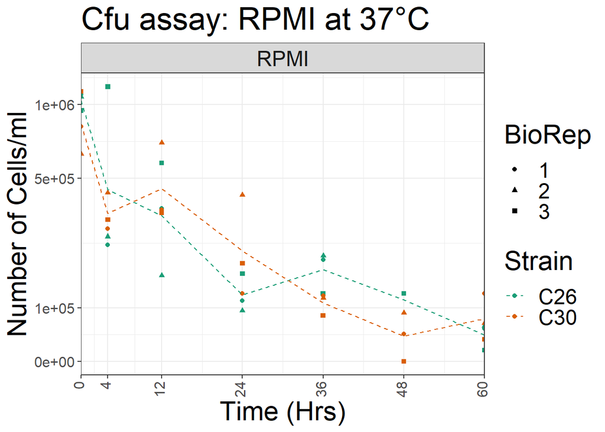

```r
rawdata_day <- mutate(rawdata,

                      BioRep=as.factor(BioRep))

Cfu_Plot_C_R <- ggplot(rawdata_day %>%
                    filter(Media == "RPMI", Strain == "C26" | Strain =="C30"),
                    aes(x=Time, y=Cells, colour = Strain)) +

    geom_point(aes(shape = BioRep), size=1.5) +
    facet_grid(~Media) +
    labs(x="Time (Hrs)",
         y="Number of Cells/ml",
         title = "Cfu assay: RPMI at 37⁰C") +
    theme(text = element_text(size = 22)) +

                   scale_x_continuous(expand = c(0, 0),  breaks = c(0, 4,12, 24,36,48,60)) +
    scale_y_continuous(trans=scales::pseudo_log_trans(sigma =100000, base =  exp(1)),
                       breaks = c(0, 100000, 500000, 1000000, 5000000))+
    theme(axis.text.x = element_text( angle = 90,hjust=1, vjust = 0.25, size = 12))+
    theme(axis.text.y = element_text(size= 12))+
    scale_color_brewer(palette="Dark2")

Cfu_Plot_mean_C_R <-  Cfu_Plot_C_R +
    stat_summary(aes(group = Strain), fun = mean, geom="line", linetype = "dashed")


Cfu_Plot_mean_C_R
```

## Create mean Cfu plot C26 + C30 in RPMI + Serum: Dash line

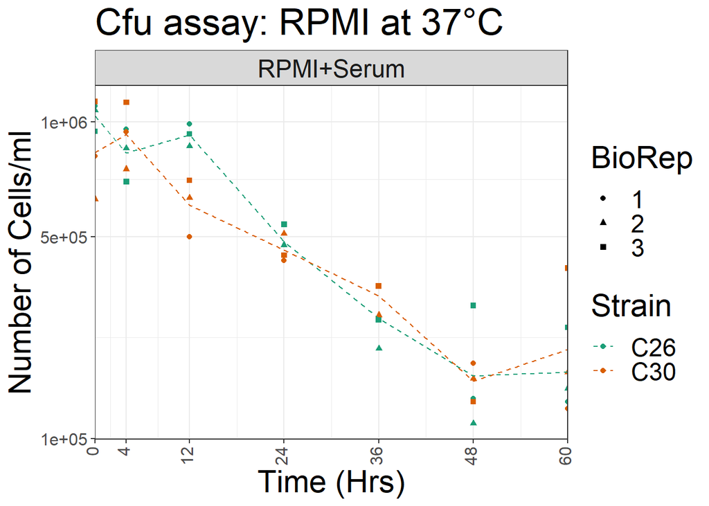

```r
rawdata_day <- mutate(rawdata,

                      BioRep=as.factor(BioRep))

Cfu_Plot_C_RS <- ggplot(rawdata_day %>%
                    filter(Media == "RPMI+Serum", Strain == "C26" | Strain =="C30"),
                    aes(x=Time, y=Cells, colour = Strain)) +

    geom_point(aes(shape = BioRep), size=1.5) +
    facet_grid(~Media) +
    labs(x="Time (Hrs)",
         y="Number of Cells/ml",
         title = "Cfu assay: RPMI at 37⁰C") +
    theme(text = element_text(size = 22)) +

                   scale_x_continuous(expand = c(0, 0),  breaks = c(0, 4,12, 24,36,48,60)) +
    scale_y_continuous(trans=scales::pseudo_log_trans(sigma =100000, base =  exp(1)),
                       breaks = c(0, 100000, 500000, 1000000, 5000000))+
    theme(axis.text.x = element_text( angle = 90,hjust=1, vjust = 0.25, size = 12))+
    theme(axis.text.y = element_text(size= 12))+
    scale_color_brewer(palette="Dark2")

Cfu_Plot_mean_C_RS <-  Cfu_Plot_C_RS +
    stat_summary(aes(group = Strain), fun = mean, geom="line", linetype = "dashed")


Cfu_Plot_mean_C_RS
```